# エラー対応

2023-05-06

# 1 エラーへの対処方法

## 1.1 TypeError: ‘str’ object is not callable

本書の第4章のプログラム4.1では、次のようなエラーが発生することがあります。

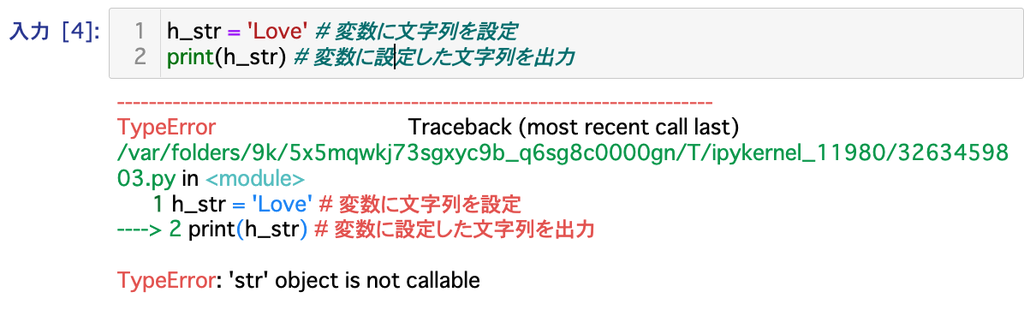

上記のプログラムの記述は正しいです。しかし、上記のプログラムよりも先に、以下のような誤ったプログラムを実行すると、print関数の中身が変化してしまうためエラーが発生します。

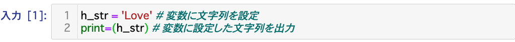

以上のエラーを解消するためには、Jupyter Notebook上で次のように作業をして、カーネルを再起動させます。- 「カーネル」をクリック- 「再起動し出力をクリアする」をクリック- カーネルを再起動し全ての出力をクリアしますか？の「再起動と全ての出力をクリア」をクリック- 下記のプログラムを再度実行

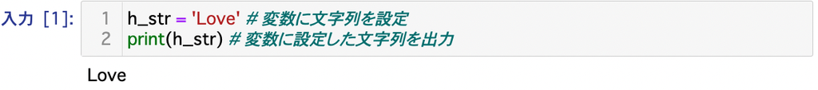

### 1.1.1 TypeError: ‘int’ object is not callable

本書の第4章のプログラム4.1では、「TypeError: ‘str’ object is not callable」と同様の理由で、次のように「TypeError: ‘int’ object is not callable」が発生することがあります。

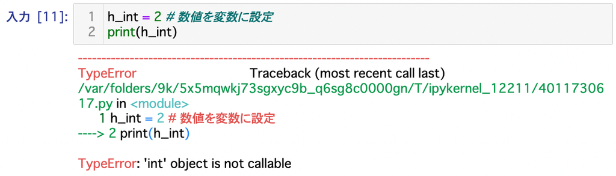

このエラーも、事前に「print=(h_int)」を実行したために発生します。対処方法は「 TypeError: ‘str’ object is not callable」のエラーと同様に、カーネルを再起動させます。

### 1.1.2 TypeError: ‘float’ object is not callable

本書の第4章のプログラム4.1では、「TypeError: ‘str’ object is not callable」と同様の理由で、次のように「TypeError: ‘float’ object is not callable」が発生することがあります。

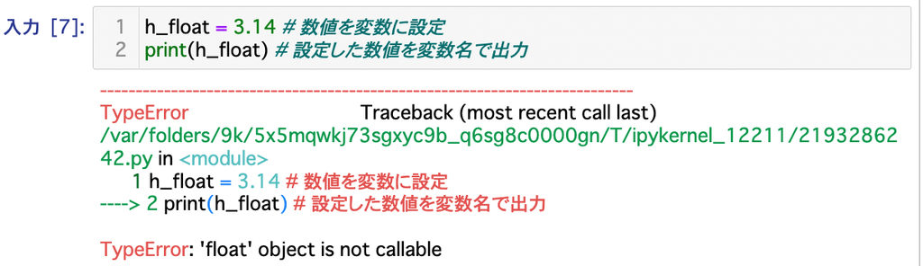

このエラーも、事前に「print=(h_float)」を実行したために発生します。対処方法は「 TypeError: ‘str’ object is not callable」のエラーと同様に、カーネルを再起動させます。

## 1.2 第6章から第8章でのエラー

### 1.2.1 NameError: name ‘np’ is not defined

授業後、課題を進めるために、Jupyter Notebookを再度開いて配列やファイル読み込みの命令を利用しようとすると、「NameError: name ‘np’ is not defined」が発生することがあります。

その際には、プログラムを作成しているセルの1行目に「import numpy as np」を挿入しましょう。

また、「import numpy as np」を「import numpy as up」と誤入力した結果、「NameError: name ‘np’ is not defined」が発生するケースもときおり見かけます。

「import numpy as np」は、現在作業しているJupyter Notebookのノートブックに、NumPyの便利な機能を使えるようにするために、その機能を読み込みます。「as np」により、本来は例えば「numpy.loadtxt()」と記述する必要がありますが、「np.loadtxt()」と記述してもNumPyの便利な機能が使えるようになります。

### 1.2.2 OSError: data//t1.csv not found.

OSError 〇〇 not found というエラーメッセージは、読者のパソコンに読み込もうとしいてるデータがないか、ファイルパスの指定に誤りがある場合に発生します。  
たとえば、原因は次のようなものがありました。

- 本書の第2.2.1項(11ページ)のとおりに、pysrcフォルダを作成していない。 - 本書の第2.2.1項の指示通りに、指定された場所に、pysrcフォルダを作成しましょう。
- 本書の第2.2.2項(12ページの図2.2)のとおりに、「jupyter notebook c://pysrc」のコマンドからJupyter Notebookを起動していない。
- Jupyter Notebookをそのまま起動したり、Anaconda Navigator から Lunch を押してJupyter Notebook を起動するのではなく、コマンドプロンプトから「jupyter notebook c://pysrc」を入力してJupyter Notebookを起動させましょう。
- 本書の第8.3.3項（83ページ）のサポートページへの移動の指示で、書籍の商品ページ「http://www.kgup.jp/book/b603529.html」 からファイルをダウンロードせずにプログラム8.5を実行している。
- 書籍の商品ページの下部からサポートページ(OneDrive)へ飛び、ファイルをダウンロードしましょう。
- ファイルをダウンロードしたが、フォルダの構成が指示と異なる。
- pysrcフォルダの内に、dataフォルダを作り、さらにそのフォルダの中にdataフォルダを作るなどの誤りがあります。pysrcフォルダ内のdataフォルダにそれぞれのファイルが保存されている状態にしましょう。

## 1.3 第9章でのエラー

発展課題9.7では次のようなエラーをみかけます。

### 1.3.1 NameError: name ‘rock’ is not defined

このエラーは、次のプログラムのように、変数名として利用されていない名前をそのまま記述したために発生しました。

```
if my_hand == rock and cpu_hand == scissors:
```

my_hand と cpu_hand は既にユーザーが入力した文字列が代入されています。しかし、rock や scissors は変数名として扱うのではなく、文字列として扱います。

そのため、以下のよう記述することで、エラーは解消します。

```
if my_hand == 'rock' and cpu_hand == 'scissors'
```

この記述により、my_handの中身の文字列が文字列rockと等しいか、かつ、cpu_hand の中身の文字列が文字列’scissors’と等しいかを判定できるようになります。

同様の理由で、「NameError: name ‘scissors’ is not defined」や「NameError: name ‘paper’ is not defined」が発生します。その際は、scissorsやpaperがシングルコーテーション「’」で囲まれていることを確認しましょう。

## 1.4 新しいMac OS のJpyter Notebook上での半角空白と全角空白

Mac OSでJupyter Notebook を利用する際、半角空白「 」と全角空白「 」が見た目上ではほぼ区別がつかない場合があります。単に見た目上の問題ではなく、次のように内部では半角空白と全角空白が区別されているためエラーが発生します。

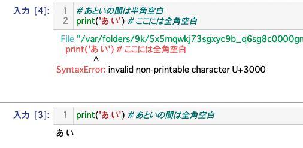

以上のように、「# ここには全角空白」の前には全角空白が挿入されているため、「SyntaxError: invalid non-printable character U+3000」が発生します。ソースコードに問題がないのに、このエラーが発生したら、全角空白を削除しましょう。

## 1.5 Mac OS対応：アニメーションエラー

### 1.5.1 はじめに

Mac OSを利用した一部のユーザーの中には、「MovieWriter ffmpeg unavailable; trying to use <class ‘matplotlib.animation.PillowWriter’> instead.」または「MovieWriter ffmpeg unavailable; using Pillow instead.」、「ValueError: unknown file extension: .mp4」などのエラーが発生する可能性があります。

- (2)のように、「ターミナル」を入力し、(3)の「ターミナル」をクリック

[figure not shown]

- ターミナルに「brew –config」を入力してエンターキーを押す。エンターキーを押した後に現れるメッセージの中の「HOMEBREW_VERSION: x.x.x」の有無を確認する（xは導入されているバージョンの数値）。

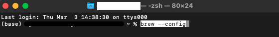

- 「-bash: brew: command not found」というメッセージが表示された場合は、[事前準備（Homebrewのインストール）]に進み作業する。
- 「HOMEBREW_VERSION: x.x.x」というメッセージが表示された場合は、[ffmpegのインストール]に進み必要なソフトウェアをインストールする

### 1.5.2 事前準備（Homebrewのインストール）

Homebrew をインストールします。

- 「https://brew.sh/index_ja」 にアクセスする。
- インストールと記載されている下の「/bin/bash -c “$(curl -fsSL https://raw.githubusercontent.com/Homebrew/install/master/install.sh)”」をコピーする
- ターミナルを起動する
- ターミナルに「/bin/bash -c “$(curl -fsSL https://raw.githubusercontent.com/Homebrew/install/master/install.sh)”」を貼り付けて、エンターキーを押す。

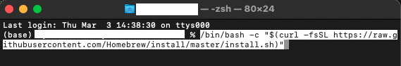

この作業はインストール完了までかなりの時間がかかります。インストールの途中で作業を進めて良いかと尋ねられたら、yes または y を入力してインストールを続けましょう。インストール完了後、次の章に進んでください。

### 1.5.3 ffmpegのインストール

ここでは動画を作成するために必要なソフトウェアをインストールします。

- ターミナルを起動する
- ターミナルに「brew install ffmpeg」を入力して、エンターキーを押す

[figure not shown]

以上の操作で「MovieWriter ffmpeg unavailable; trying to use <class ‘matplotlib.animation.PillowWriter’> instead.」が多くの場合解消されます。実際にプログラムを動かしてみましょう。

## 1.6 実行しても何も反映されない(Markdownの場合)

Jupyter Notebookのセルに記述したプログラムを実行しても以下の画面の(2)ように、 何も実行結果が表示されない場合があります。この原因は(1)のように、 文章を記述するモード(Markdown)になっていることが原因です。

[figure not shown]

上記のように誤操作でMarkdownを選択し、その後手が止まる読者がいます。その際は、下記の画面の(3)のCodeを選択します。これで(4)のようにPythonのプログラムを実行できるようになります。

[figure not shown]